# R Notebook

```r
#install.packages("EnvStats")
#library(foreach) #To do parallel computiong

library(EnvStats)
library(foreach)
```

# Simulation

### set general parameters

```r
rm(list = ls())

pars = list()

# General parameters
#pars$int = 0 # 0 for competition, 1 for facilitation, 2 for predation
pars$Smax = 1000 # Maximal number of species in the system

# Related to interaction range trait
pars$av_r = 0.1 # Half range of the niche of the first species
pars$sd = 0.5*pars$av_r + 0.0001 # Standard deviation of the normal distribution used to calculate the niche optimum trait of a new species

pars$u_max = 0.15 # Speciation probability

# Extinction probability, negative interactions communities
pars$a_eneg = 0.025 # Shape of the exponential decay of the negative extinction - interaction relationship
pars$e_0neg = 0.5 # Asymptotic extinction probability with infinite negative interactions
pars$e_1neg = 1  # Extinction probability with absence of interactions

# Extinction probability, positive interactions communities
pars$a_epos = 1.2  # Shape of the exponential decay of the positive extinction - interaction relationship
pars$e_0pos = 0.075 # Asymptotic extinction probability with infinite positive interactions
pars$e_1pos = 5.19 # 1 - pars$e_0pos

# Establishment probability, negative interactions communities
pars$a_uneg = 0.075 # Shape of the exponential decay of the colonization - interaction relationship
pars$u_0neg = 0.075 # Asymptotic establishment probability with infinite competition interactions
pars$u_1neg = 2 # Establishment probability with absence of competition interaction

# Establishment probability, positive interactions communities
pars$a_u = 0.45 # Shape of the exponential decay of the colonization - interaction relationship
pars$u_0 = 1 # Asymptotic establishment probability with infinite facilitation interactions
pars$u_1 = -1 # Establishment probability with absence of facilitation interactions
pars$d = 0.5 # Decrease speed of the establishment probability

# Extinction and establishment probabilitie for both, positive and negative interactions communities
pars$Bspe = 4 # Constant minimal number of interaction per species (extablishment prob)
pars$Bext = 4 # Constant minimal number of interaction per species (extinction prob)
pars$I_max = 40 # Maximal number of interactioning species
```

```r
pars$e_0neg = 0.1 # Asymptotic extinction probability with infinite negative interactions
```

```r
source("./functions_fw_only.R")
source("../Original_code/functions/list_append_function.R")
```

### set parameters simulation

```r
nsteps = 350 # Set the maximum timestep per simulation
nsim = 1 # Set the number of simulations

# Vector to record number of simulation needed to reach 100 valid simulations
needed_sim_pos <- c(rep(NA, nsim))
needed_sim_neg <- c(rep(NA, nsim))
needed_sim_fw <- c(rep(NA, nsim))
```

### Seeds record matrix

```r
# List of used seed per simulation batch
reccorded_seed_pos_list <- list()
reccorded_seed_neg_list <- list()
reccorded_seed_fw_list <- list()

seed_list <- NULL # Set an object to record seed that will be used to launch simulations
```

## Simulation

```r
reccorded_seed_fw_list
```

```
[[1]]
[1] 24838

[[2]]
[1] 44564
```

```r
names(list_res)
```

```
[1] "simulation1"
```

## Spp richness through time

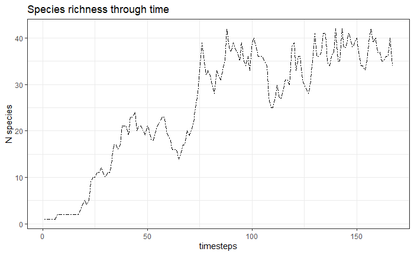

### save data

```r
save(reccorded_seed_fw_list, file = "../AF_Data/foodweb/reccorded_seed_neg_list1.Rdata")
save(needed_sim_fw, file = "../AF_Data/foodweb/needed_sim_fw.Rdata")
```

— How results are stored They are stored in list_res_pos_nsim.Rdata and list_res_neg_nsim.Rdata in the form of a list (list_res), which is a list of simulations, and each of them contains a list of the results of the simulation (res_sim). I need to think about a way to combine the results of the simulations (phylog. signal) -> maybe statistic describing the relationship between phylog. signal and time, dimensionality, etc..

— The simulation ends if it reaches either a maximum number of timesteps (350) or a maximum number of species (1000). To make sure the list of networks and the list of trees per timesteps have (1) the same length and (2) are correspondent with the timesteps, I need to make sure that both start and finish to be measured at the same timesteps, and that I know then number of timesteps run per simulation.

Start: 5 species present could be a good number for starting to measure both networks and phylogenies. For the trees, I calculate them from the anc table. Networks are stored in a list.

So list_networks[[5]] should be compared with anc[[timestep 5]]

— Phylogenetic distances Record them myself rather than with hclust or any other algorythm. Pass distances data to Netweek format.